# Отчет по домашней работе №2

## Набор данных 1

Клиническое исследование посвящено влиянию диеты на активность фермента амилазы. Добровольцы, согласившиеся принять участие в исследовании, случайным образом были распределены по группам и стали соблюдать определенную диету. Через две недели у всех добровольцев была измерена активность амилазы (условные единицы). Результаты представлены на листе activity, который сохранен в файле hw2.shelepin.data.xlsx.

```r
# install.packages("pacman")
pacman::p_load(readxl, ggplot2, dplyr, nortest, car, tidyverse, scales, emmeans, multcomp, multcompView, gtsummary, knitr)
```

1. Загрузите необходимые данные из файла hw2.shelepin.data.xlsx

```r
hw2_data <- read_excel("hw2.shelepin.data.xlsx", sheet = "activity")
kable(summary(hw2_data))
```

|  | type | rate |
| --- | --- | --- |
|  | Length:60 | Min. : 43.67 |
|  | Class :character | 1st Qu.: 52.19 |
|  | Mode :character | Median : 58.24 |
|  | NA | Mean : 60.41 |
|  | NA | 3rd Qu.: 66.50 |
|  | NA | Max. :100.00 |

2. Рассчитайте описательные статистики и заполните таблицу

```r
result <- hw2_data %>%
  group_by(type) %>%
  summarise(
    Среднее = mean(rate),
    Дисперсия = var(rate),
    Стандартное_отклонение = sd(rate),
    Объем_выборки = n(),
    Минимум = min(rate),
    Максимум = max(rate)
  )

kable(result)
```

| type | Среднее | Дисперсия | Стандартное_отклонение | Объем_выборки | Минимум | Максимум |
| --- | --- | --- | --- | --- | --- | --- |
| белково-бургерная | 64.33894 | 105.30563 | 10.261853 | 16 | 46.561 | 83 |
| раздельное питание | 67.68643 | 206.28605 | 14.362662 | 14 | 46.355 | 100 |
| средиземноморская | 56.65836 | 97.77743 | 9.888247 | 14 | 43.668 | 74 |
| фруктово-ягодно-овощная | 53.38112 | 65.56294 | 8.097094 | 16 | 44.030 | 71 |

3. Преобразуйте фактор таким образом, чтобы категории следовали в порядке роста средней активности амилазы. Переименуйте имена категорий для более компактного отображения на графиках (сократите имена, можно использовать аббревиатуры)

```r
means <- aggregate(rate ~ type, data = hw2_data, FUN = mean)
means <- means[order(means$rate), ]

abbreviations <- c(
  "белково-бургерная" = "ББ",
  "раздельное питание" = "РП",
  "средиземноморская" = "СМ",
  "фруктово-ягодно-овощная" = "ФЯО"
)

hw2_data$type_n <- factor(hw2_data$type,
                          levels = means$type,
                          labels = abbreviations[means$type])

# Проверяем результат
levels(hw2_data$type_n)
```

```
## [1] "ФЯО" "СМ"  "ББ"  "РП"
```

```r
result <- hw2_data %>%
  group_by(type_n) %>%
  summarise(
    Среднее = mean(rate),
    Дисперсия = var(rate),
    Стандартное_отклонение = sd(rate),
    Объем_выборки = n(),
    Минимум = min(rate),
    Максимум = max(rate)
  )

# Вывод результата
kable(result)
```

| type_n | Среднее | Дисперсия | Стандартное_отклонение | Объем_выборки | Минимум | Максимум |
| --- | --- | --- | --- | --- | --- | --- |
| ФЯО | 53.38112 | 65.56294 | 8.097094 | 16 | 44.030 | 71 |
| СМ | 56.65836 | 97.77743 | 9.888247 | 14 | 43.668 | 74 |
| ББ | 64.33894 | 105.30563 | 10.261853 | 16 | 46.561 | 83 |
| РП | 67.68643 | 206.28605 | 14.362662 | 14 | 46.355 | 100 |

4. Сформируйте модель дисперсионного анализа исследуемой зависимости

```r
fit <- lm(rate ~ type_n, data = hw2_data)
summary(fit)
```

```
##
## Call:
## lm(formula = rate ~ type_n, data = hw2_data)
##
## Residuals:
##     Min      1Q  Median      3Q     Max
## -21.331  -7.665  -1.259   6.314  32.314
##
## Coefficients:
##             Estimate Std. Error t value Pr(>|t|)
## (Intercept)   53.381      2.697  19.795  < 2e-16 ***
## type_nСМ       3.277      3.948   0.830 0.409955
## type_nББ      10.958      3.814   2.873 0.005730 **
## type_nРП      14.305      3.948   3.624 0.000627 ***
## ---
## Signif. codes:  0 '***' 0.001 '**' 0.01 '*' 0.05 '.' 0.1 ' ' 1
##
## Residual standard error: 10.79 on 56 degrees of freedom
## Multiple R-squared:  0.2327, Adjusted R-squared:  0.1916
## F-statistic:  5.66 on 3 and 56 DF,  p-value: 0.001851
```

5. Проанализируйте характер распределения остатков. Примените три критерия согласия. Приведите p-значения и сделайте итоговый вывод.

```r
residuals <- residuals(fit)

# 1. Критерий Шапиро-Уилка
shapiro_test <- shapiro.test(residuals)
# 2. Критерий Лиллиефорса
lillie <- lillie.test(residuals)
# 3. Критерий Андерсона-Дарлинга
ad_test <- ad.test(residuals)
```

```r
p_values <- data.frame(
  Test = c("Шапиро-Уилка", "Лиллиефорса", "Андерсона-Дарлинга"),
  `p-value` = c(shapiro_test$p.value, lillie$p.value, ad_test$p.value)
)
kable(p_values, col.names = c("Критерий", "p-value"))
```

| Критерий | p-value |
| --- | --- |
| Шапиро-Уилка | 0.0102402 |
| Лиллиефорса | 0.0043695 |
| Андерсона-Дарлинга | 0.0018242 |

Во всех тестах p-value < 0.05. Следовательно, мы **отвергаем нулевую гипотезу о нормальности распределения**. Также посмотрим на Q-Q график и гистограмму остатков.

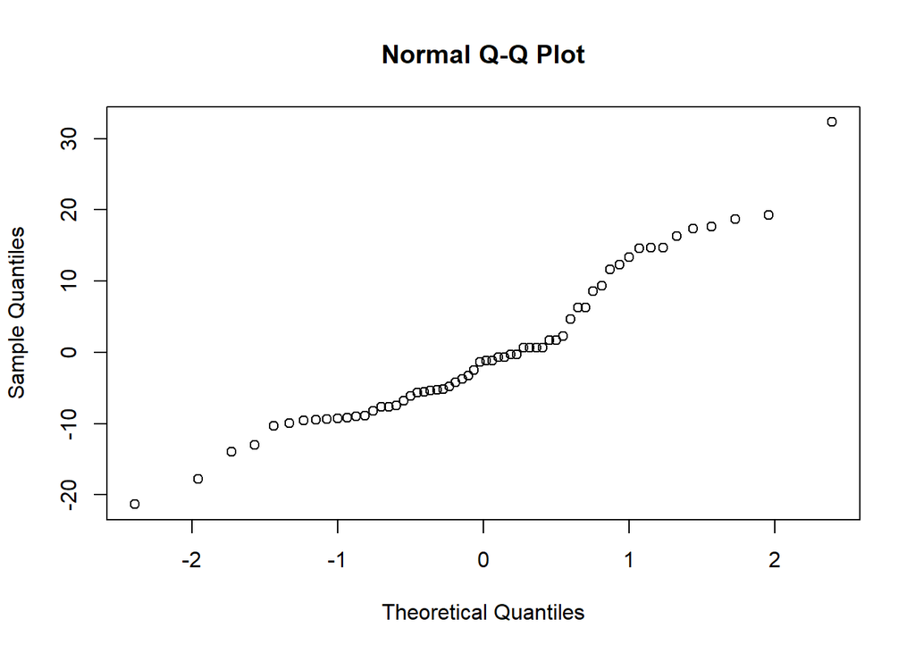

```r
# Q-Q график
qqnorm(residuals)
```

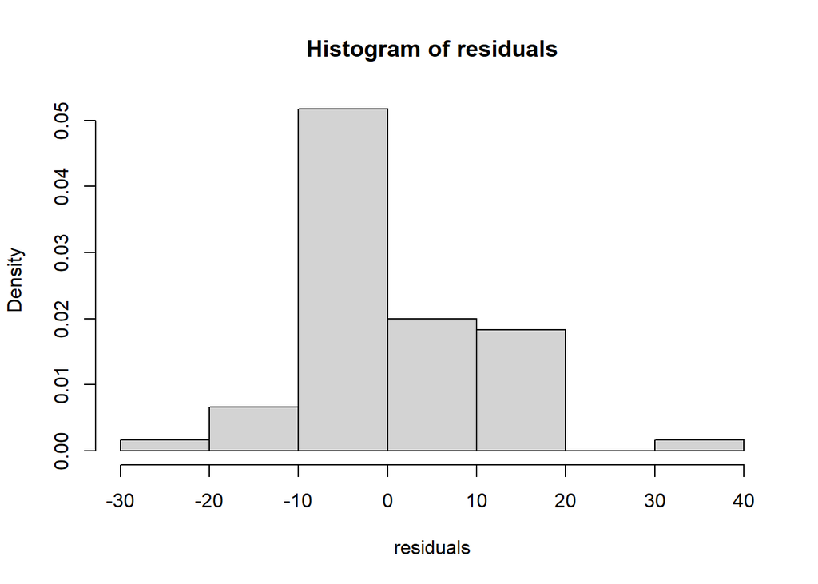

```r
# Гистограмма остатков
hist(residuals, freq = FALSE)
```

Наблюдается **скошенность распределения вправо**.

6. Проведите анализ влияния диеты на активность амилазы с использованием процедуры, соответствующей характеру распределения данных. Укажите название критерия, p-значение и сделайте итоговый вывод.

Так как мы отвергнули нулевую гипотезу о нормальности распределения, воспользуемся **критерием Крускала-Уоллиса**:

```r
kruskal.test(rate ~ type_n, data = hw2_data)
```

```
##
##  Kruskal-Wallis rank sum test
##
## data:  rate by type_n
## Kruskal-Wallis chi-squared = 15.278, df = 3, p-value = 0.001594
```

Нулевая гипотеза в тесте Краскела-Уоллиса предполагает, что все группы имеют одинаковое распределение (или одинаковые медианы). p-value (0.001594) значительно меньше 0.05 – **мы отвергаем нулевую гипотезу**.  
Отвержение нулевой гипотезы указывает на то, что существуют статистически значимые различия между группами.

Вывод: Существуют статистически значимые различия в распределении переменной “rate” между четырьмя группами, определенными переменной “type_n”. Иными словами, type_n оказывает существенное влияние на rate.

7. Проведите попарные сравнения средних с применением наиболее мощной процедуры, соответствующей распределению данных. Какие пары выборок отличаются по средней активности амилазы?

Воспользуемся **критерием Уилкоксона**:

```r
suppressWarnings(pairwise.wilcox.test(hw2_data$rate, hw2_data$type_n))
```

```
##
##  Pairwise comparisons using Wilcoxon rank sum test with continuity correction
##
## data:  hw2_data$rate and hw2_data$type_n
##
##    ФЯО    СМ     ББ
## СМ 0.8832 -      -
## ББ 0.0098 0.1592 -
## РП 0.0098 0.0809 0.8832
##
## P value adjustment method: holm
```

Пары выборок **значительно** отличаются по средней активности, если p-value < 0.05. Это пары:

ФЯО-ББ  
ФЯО-РП

8. Составьте систему компактных буквенных обозначений, отражающих значимость попарных сравнений.

```r
model_means <- emmeans(object = fit,
                       specs = "type_n")
model_means_cld <- cld(object = model_means,
                       Letters = letters,
                       alpha = 0.05)
model_means_cld
```

```
##  type_n emmean   SE df lower.CL upper.CL .group
##  ФЯО      53.4 2.70 56     48.0     58.8  a
##  СМ       56.7 2.88 56     50.9     62.4  ab
##  ББ       64.3 2.70 56     58.9     69.7   bc
##  РП       67.7 2.88 56     61.9     73.5    c
##
## Confidence level used: 0.95
## P value adjustment: tukey method for comparing a family of 4 estimates
## significance level used: alpha = 0.05
## NOTE: If two or more means share the same grouping symbol,
##       then we cannot show them to be different.
##       But we also did not show them to be the same.
```

9. Для визуализации результатов попарных сравнений постройте диаграмму размахов с компактными буквенными обозначениями. Отдельные диаграммы должны быть залиты разными цветами. Буквенные обозначения должны располагаться под диаграммами. Сверху от диаграмм разместите стрелку, указывающую в сторону увеличения средней активности амилазы. Вставьте полученный график в итоговый отчет.

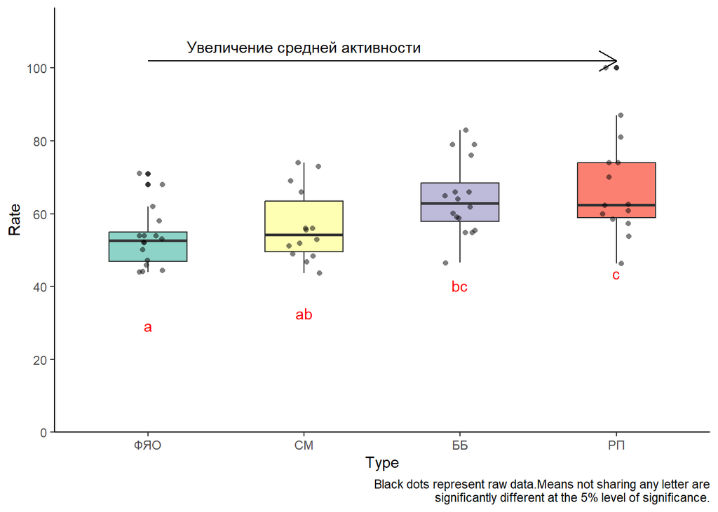

```r
model_means_cld <- model_means_cld %>%
  mutate(type_n = fct_reorder(type_n, emmean))

hw2_data <- hw2_data %>%
  mutate(type_n = fct_relevel(type_n, levels(model_means_cld$type_n)))

ggplot() +
  scale_y_continuous(
    name = "Rate",
    limits = c(0, NA),
    breaks = pretty_breaks(),
    expand = expansion(mult = c(0,0.1))
  ) +
  scale_x_discrete(
    name = "Type"
  ) +
  theme_classic() +
  geom_boxplot(
    data = hw2_data,
    aes(y = rate, x = type_n, fill = type_n),
    width = 0.5
  ) +
  scale_fill_brewer(palette = "Set3") +
  geom_point(
    data = hw2_data,
    aes(y = rate, x = type_n),
    shape = 16,
    alpha = 0.5,
    position = position_jitter(width = 0.1)
  ) +
  geom_text(
    data = model_means_cld,
    aes(
      y = emmean,
      x = type_n,
      label = str_trim(.group)
    ),
    position = position_nudge(x = 0, y = -24),
    hjust = 0.5,
    color = "red"
  ) +
  annotate("segment",
           x = 1,
           xend = length(unique(hw2_data$type_n)),
           y = max(hw2_data$rate) + 2,
           yend = max(hw2_data$rate) + 2,
           arrow = arrow(length = unit(0.5, "cm"))) +
  annotate("text",
           x = length(unique(hw2_data$type_n))/2,
           y = max(hw2_data$rate) + 6,
           label = "Увеличение средней активности") +
  theme(legend.position = "none") +
  labs(
    caption = str_wrap("Black dots represent raw data.Means not sharing any letter are significantly different at the 5% level of significance.", width = 70)
  )
```